# 데이터 시각화 - 인터랙티브

시가총액 10년 변화 - 경주하는 막대그래프

[Tidyverse Korea](https://www.facebook.com/groups/tidyverse/)

2020-03-20

# 1 데이터

[데이터셋 - 시가총액 데이터](https://financedata.github.io/marcap/)는 [FinanceData.KR](https://web.facebook.com/financedata) 이승준 대표님이 한국거래소 홈페이지를 통해서 얻을 수 있는 정보를 개발자가 사용하기 편한 상태로 GitHub에 공개하여 활용할 수 있게 도움을 주고 있다.

## 1.1 GitHub →

먼저 다음 명령어로 로컬 컴퓨터에 저장시킨다.

```bash
git clone "https://github.com/FinanceData/marcap.git" marcap
```

다음으로 파이썬 유틸리티 함수를 사용해서 경주하는 막대그래프를 제작하는데 용이한 형태로 데이터를 변환시키는 것도 가능한데 `marcap` 파이썬 데이터 팩키지를 자세히 보면 원본 데이터는 압축한 `.csv` 파일이라 바로 `tidyverse` `read_csv()` 함수를 사용해서 읽어들일 수가 있다.

## 1.2 1년치 데이터

가장 최근 2019년 시가총액 데이터를 읽어와서 상위 10개 상장사 월별 시가총액을 구해보자.

```r
library(tidyverse)

df <- read_csv("marcap/data/marcap-2019.csv.gz")

month_df <- df %>%
  janitor::clean_names() %>%
  mutate(marcap = round(marcap / 10^12, 1)) %>%
  mutate(yearmon = format(date, "%Y-%m")) %>%
  group_by(name, yearmon) %>%
  arrange(date) %>%
  slice(n()) %>%
  ungroup()

month_10_df <- month_df %>%
  group_by(yearmon) %>%
  top_n(10, marcap) %>%
  select(name, marcap, yearmon, rank) %>%
  ungroup()

month_10_df %>%
  arrange(rank) %>%
  DT::datatable()
```

|  | name | marcap | yearmon | rank |
| --- | --- | --- | --- | --- |
| 1 | 삼성전자 | 275.5 | 2019-01 | 1 |
| 2 | 삼성전자 | 269.2 | 2019-02 | 1 |
| 3 | 삼성전자 | 266.6 | 2019-03 | 1 |
| 4 | 삼성전자 | 273.7 | 2019-04 | 1 |
| 5 | 삼성전자 | 254 | 2019-05 | 1 |
| 6 | 삼성전자 | 280.6 | 2019-06 | 1 |
| 7 | 삼성전자 | 270.7 | 2019-07 | 1 |
| 8 | 삼성전자 | 262.7 | 2019-08 | 1 |
| 9 | 삼성전자 | 292.8 | 2019-09 | 1 |
| 10 | 삼성전자 | 300.9 | 2019-10 | 1 |

[output cut: 111 more lines]

## 1.3 함수

### 1.3.1 인자없는 함수

다음으로 상위 10개 상장사를 뽑아내는 함수를 만들어보자. 먼저 앞서 작성한 스크립트를 인자를 받지 않는 함수로 작성한다. 그리고 나서 함수를 호출하여 결과값을 비교한다.

```r
get_10_marcap <- function() {
  year_df <- read_csv("marcap/data/marcap-2019.csv.gz")

  year_month_df <- year_df %>%
    janitor::clean_names() %>%
    mutate(marcap = round(marcap / 10^12, 1)) %>%
    mutate(yearmon = format(date, "%Y-%m")) %>%
    group_by(name, yearmon) %>%
    arrange(date) %>%
    slice(n()) %>%
    ungroup()

  year_month_10_df <- year_month_df %>%
    group_by(yearmon) %>%
    top_n(10, marcap) %>%
    select(name, marcap, yearmon, rank) %>%
    ungroup() %>%
    arrange(rank)

  return(year_month_10_df)
}

sample_df <- get_10_marcap()

sample_df %>%
  DT::datatable()
```

|  | name | marcap | yearmon | rank |
| --- | --- | --- | --- | --- |
| 1 | 삼성전자 | 275.5 | 2019-01 | 1 |
| 2 | 삼성전자 | 269.2 | 2019-02 | 1 |
| 3 | 삼성전자 | 266.6 | 2019-03 | 1 |
| 4 | 삼성전자 | 273.7 | 2019-04 | 1 |
| 5 | 삼성전자 | 254 | 2019-05 | 1 |
| 6 | 삼성전자 | 280.6 | 2019-06 | 1 |
| 7 | 삼성전자 | 270.7 | 2019-07 | 1 |
| 8 | 삼성전자 | 262.7 | 2019-08 | 1 |
| 9 | 삼성전자 | 292.8 | 2019-09 | 1 |
| 10 | 삼성전자 | 300.9 | 2019-10 | 1 |

[output cut: 111 more lines]

### 1.3.2 연도인자 함수

다음으로 연도 인자를 받는 함수를 작성해서 테스트 해 본다.

```r
get_10_marcap <- function(marcap_data) {
  year_df <- read_csv(marcap_data)

  year_month_df <- year_df %>%
    janitor::clean_names() %>%
    mutate(marcap = round(marcap / 10^12, 1)) %>%
    mutate(yearmon = format(date, "%Y-%m")) %>%
    group_by(name, yearmon) %>%
    arrange(date) %>%
    slice(n()) %>%
    ungroup()

  year_month_10_df <- year_month_df %>%
    group_by(yearmon) %>%
    top_n(10, marcap) %>%
    select(name, marcap, yearmon, rank) %>%
    ungroup() %>%
    arrange(rank)

  return(year_month_10_df)
}

sample_argv_df <- get_10_marcap("marcap/data/marcap-2019.csv.gz")

sample_argv_df %>%
  DT::datatable()
```

|  | name | marcap | yearmon | rank |
| --- | --- | --- | --- | --- |
| 1 | 삼성전자 | 275.5 | 2019-01 | 1 |
| 2 | 삼성전자 | 269.2 | 2019-02 | 1 |
| 3 | 삼성전자 | 266.6 | 2019-03 | 1 |
| 4 | 삼성전자 | 273.7 | 2019-04 | 1 |
| 5 | 삼성전자 | 254 | 2019-05 | 1 |
| 6 | 삼성전자 | 280.6 | 2019-06 | 1 |
| 7 | 삼성전자 | 270.7 | 2019-07 | 1 |
| 8 | 삼성전자 | 262.7 | 2019-08 | 1 |
| 9 | 삼성전자 | 292.8 | 2019-09 | 1 |
| 10 | 삼성전자 | 300.9 | 2019-10 | 1 |

[output cut: 111 more lines]

## 1.4 반복

### 1.4.1 반복 준비

연도별 인자를 받는 함수를 작성했기 때문에 연도별 파일을 넣어주고 이를 해당연도만큼 반복을 하면 원하는 데이터를 얻을 수가 있다. 이를 위해서 함수 인자로 넣어줄 연도별 파일인자를 정의하는 작업이 추가된다. `fs` 팩키지를 바탕으로 연도별 시가총액 데이터가 들어있는 디렉토리를 찾아 디렉토리명이 포함된 파일명(`file_name`)을 벡터로 만들고 가장 최근 파일(`file_name[length(file_name)]`)을 시험삼아 검증한다.

```r
library(fs)

file_name <- dir_ls("marcap/data")

sample_loop_df <- get_10_marcap(file_name[length(file_name)])

sample_loop_df %>%
  DT::datatable()
```

|  | name | marcap | yearmon | rank |
| --- | --- | --- | --- | --- |
| 1 | 삼성전자 | 275.5 | 2019-01 | 1 |
| 2 | 삼성전자 | 269.2 | 2019-02 | 1 |
| 3 | 삼성전자 | 266.6 | 2019-03 | 1 |
| 4 | 삼성전자 | 273.7 | 2019-04 | 1 |
| 5 | 삼성전자 | 254 | 2019-05 | 1 |
| 6 | 삼성전자 | 280.6 | 2019-06 | 1 |
| 7 | 삼성전자 | 270.7 | 2019-07 | 1 |
| 8 | 삼성전자 | 262.7 | 2019-08 | 1 |
| 9 | 삼성전자 | 292.8 | 2019-09 | 1 |
| 10 | 삼성전자 | 300.9 | 2019-10 | 1 |

[output cut: 111 more lines]

## 1.5 전체 반복

`file_name`벡터의 연도별 시가총액을 `map_df()` 함수에 넣어 이를 데이터프레임으로 결합시켜 하나의 데이터프레임으로 뽑아내서 로컬 파일로 저장시킨다.

```r
marcap_df <- map_df(file_name, get_10_marcap)

marcap_df %>%
  mutate(yearmon = as.Date(paste0(yearmon, "-15"))) %>%
  write_rds("data/marcap_df.rds")
```

# 2 정적 시각화

## 2.1 특정연도 막대그래프

가장 최근 특정연도를 2019로 선정하여 월별 시가총액 변화를 `ggplot`으로 막대그래프를 제작한다.

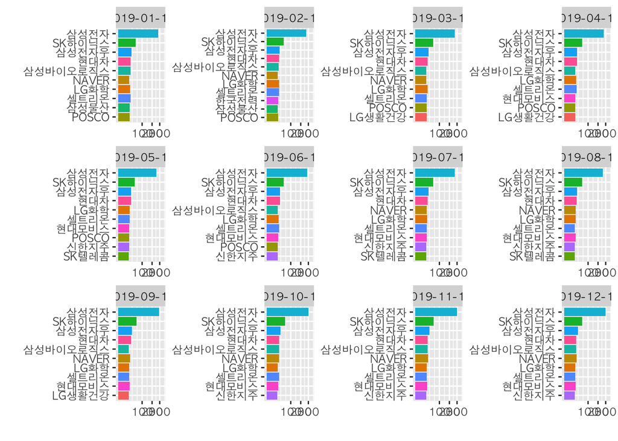

```r
marcap_df <- read_rds("data/marcap_df.rds")

marcap_df %>%
  filter(str_detect(yearmon, "2019")) %>%
  ggplot(aes(x=fct_reorder(name, marcap), y=marcap, fill=name)) +
    geom_col(show.legend = FALSE) +
    coord_flip() +
    facet_wrap(~yearmon, scales = "free") +
    labs(x="", y="") +
    scale_y_sqrt(limits=c(0,350))
```

## 2.2 디자인 입히기

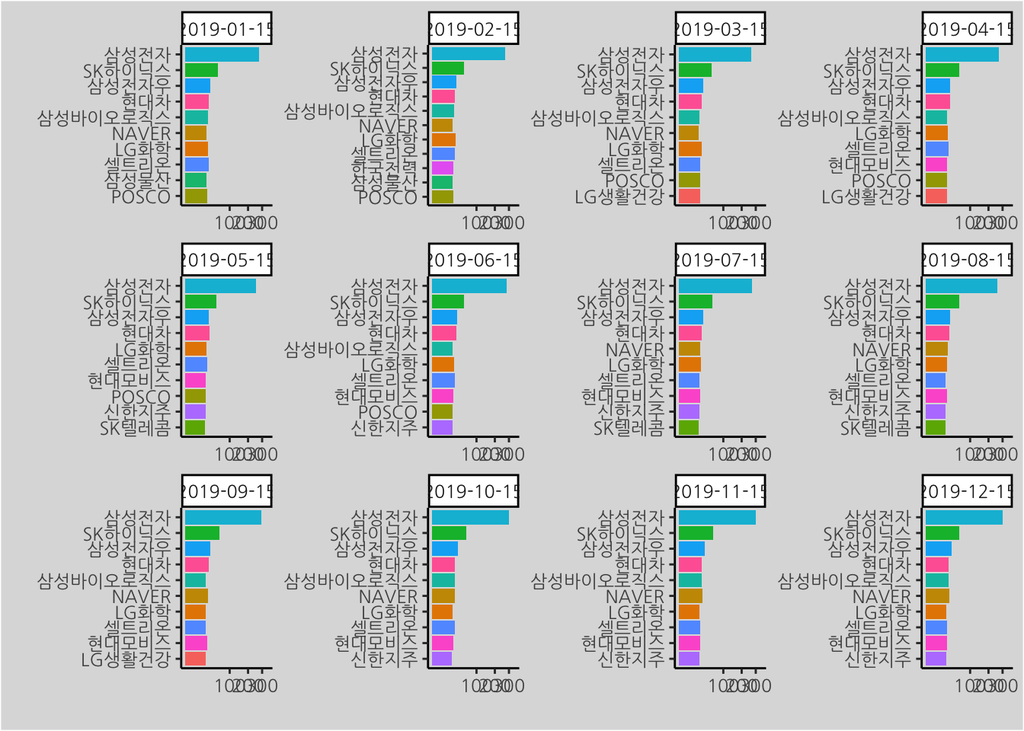

```r
library(extrafont)
loadfonts()

marcap_theme <- theme_classic(base_family = "NanumGothic") +
  # theme(axis.text.y = element_blank()) +
  # theme(axis.ticks.y = element_blank()) +
  # theme(axis.line.y = element_blank()) +
  theme(legend.background = element_rect(fill = "gainsboro")) +
  theme(plot.background = element_rect(fill = "gainsboro")) +
  theme(panel.background = element_rect(fill = "gainsboro"))

marcap_g <- marcap_df %>%
  filter(str_detect(yearmon, "2019")) %>%
  ggplot(aes(x=fct_reorder(name, marcap), y=marcap, fill=name)) +
    geom_col(show.legend = FALSE) +
    coord_flip() +
    facet_wrap(~yearmon, scales = "free") +
    labs(x="", y="") +
    scale_y_sqrt(limits=c(0,350)) +
    marcap_theme

marcap_g
```

## 2.3 애니메이션

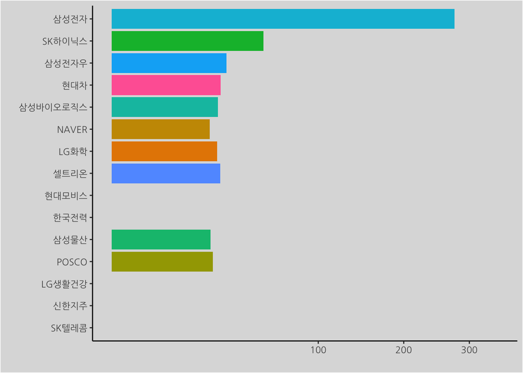

```r
library(gganimate)
options(gganimate.nframes = 20)

marcap_g +
  facet_null() +
  geom_text(x = 300 , y = -10,
            family = "Times",
            aes(label = as.character(yearmon)),
            size = 30, col = "grey18") +
  aes(group = name) +
  gganimate::transition_time(yearmon)
```